# Genome_summary

2026-02-23

# Genome summary

This document contains the code for running the statistical analyses and data visualization for the nodule trapping data.

# Load required libraries

```r
library(lme4)
library(phyloseq)
library(car)
library(emmeans)
library(ggplot2)
library(patchwork)
library(vegan)
library(dplyr)
library(tidyr)
library(kableExtra)
library(tibble)
library(tidyverse)
library(UpSetR)
library(gplots)
library(gggenes)
library(RColorBrewer)
```

# Statistical analysis of the genome metrics

Examine if genome size and replicon number differs significantly across specie

```r
# Load the data
data <- read.table("genome_stats.txt",
                   header = TRUE, row.names = NULL)
```

First check if genome size is statistically different across species

```r
# Perform statistical analysis on genome size
model.size <- lm(genome_size ~ Species, data=data)
summary(model.size)
```

```
##
## Call:
## lm(formula = genome_size ~ Species, data = data)
##
## Residuals:
##     Min      1Q  Median      3Q     Max
## -321305  -78320  -20152   63481  609785
##
## Coefficients:
##                                 Estimate Std. Error t value Pr(>|t|)
## (Intercept)                      7347878      28320 259.458  < 2e-16 ***
## SpeciesRhizobium_binxianense     -387474      65402  -5.924 1.31e-08 ***
## SpeciesRhizobium_croatiense      -727635      32501 -22.388  < 2e-16 ***
## SpeciesRhizobium_hidalgonense    -475698     147156  -3.233  0.00143 **
## SpeciesRhizobium_johnstonii       209348      41336   5.065 9.10e-07 ***
## SpeciesRhizobium_laguerreae       247288      88051   2.808  0.00546 **
## SpeciesRhizobium_leguminosarum    240692      40449   5.950 1.14e-08 ***
## SpeciesRhizobium_mongolense       -67076      77558  -0.865  0.38813
## SpeciesRhizobium_sophoriradicis  -403061      38693 -10.417  < 2e-16 ***
## SpeciesRhizobium_spA             -292379      51940  -5.629 5.91e-08 ***
## SpeciesRhizobium_spB               32246      70516   0.457  0.64795
## ---
## Signif. codes:  0 '***' 0.001 '**' 0.01 '*' 0.05 '.' 0.1 ' ' 1
##
## Residual standard error: 144400 on 205 degrees of freedom
## Multiple R-squared:  0.8843, Adjusted R-squared:  0.8786
## F-statistic: 156.6 on 10 and 205 DF,  p-value: < 2.2e-16
```

```r
#model.size.aov <- Anova(model.size, type = 2)
#model.size.em <- emmeans(model.size, pairwise ~ Species,
#                         infer = TRUE, type = "response")
#model.size.em$emmeans
#model.size.em$contrasts
```

Genome size is statistically different across species.

Now check if the number of replicons differs, limited to only complete genomes

```r
# Perform statistical analysis on replicon count
data.complete <- data[data$genome_status == "complete", ]
model.replicon <- lm(contig_count ~ Species, data=data.complete)
summary(model.replicon)
```

```
##
## Call:
## lm(formula = contig_count ~ Species, data = data.complete)
##
## Residuals:
##      Min       1Q   Median       3Q      Max
## -1.28571 -0.06684  0.00000  0.04348  1.71429
##
## Coefficients:
##                                 Estimate Std. Error t value Pr(>|t|)
## (Intercept)                       5.2857     0.1649  32.059  < 2e-16 ***
## SpeciesRhizobium_croatiense       1.6708     0.1770   9.441 2.52e-16 ***
## SpeciesRhizobium_hidalgonense    -1.2857     0.4663  -2.757 0.006700 **
## SpeciesRhizobium_johnstonii       0.7731     0.1959   3.946 0.000131 ***
## SpeciesRhizobium_laguerreae       1.7143     0.3498   4.901 2.87e-06 ***
## SpeciesRhizobium_leguminosarum   -0.1948     0.1893  -1.029 0.305403
## SpeciesRhizobium_mongolense      -1.2857     0.3010  -4.271 3.80e-05 ***
## SpeciesRhizobium_sophoriradicis   0.7143     0.1865   3.829 0.000202 ***
## SpeciesRhizobium_spA              2.3393     0.2258  10.362  < 2e-16 ***
## SpeciesRhizobium_spB              0.7143     0.2554   2.796 0.005977 **
## ---
## Signif. codes:  0 '***' 0.001 '**' 0.01 '*' 0.05 '.' 0.1 ' ' 1
##
## Residual standard error: 0.4362 on 126 degrees of freedom
## Multiple R-squared:  0.8029, Adjusted R-squared:  0.7888
## F-statistic: 57.03 on 9 and 126 DF,  p-value: < 2.2e-16
```

```r
#model.replicon.aov <- Anova(model.replicon, type = 2)
#model.replicon.em <- emmeans(model.replicon, pairwise ~ Species,
#                         infer = TRUE, type = "response")
#model.replicon.em$emmeans
#model.replicon.em$contrasts
```

Replicon count is statistically different across species.

Now clear the workspace in preparation for next analyses.

```r
# Clean the workspace
rm(list = ls())
```

# Summarize genome metrics

Prepare tables with summary statistics for the genome metrics of interest

```r
# Load the data
data <- read.table("genome_stats.txt",
                   header = TRUE, row.names = NULL)
```

Prepare summary statistics for genome size.

```r
# Get summary metrics for genome size
genome.size.stats <- data %>%
  group_by(Species) %>%
  summarize(Count = n(),
            Mean = round(mean(genome_size, na.rm = TRUE), 0),
            Median = round(median(genome_size, na.rm = TRUE), 0),
            SD = round(sd(genome_size, na.rm = TRUE), 0),
            Min = round(min(genome_size, na.rm = TRUE), 0),
            Max = round(max(genome_size, na.rm = TRUE), 0))

# Create a table rounded to 0 decimal place
kable(genome.size.stats, align = "l",
      caption = "Genome size statistics") %>%
  kable_classic(full_width = FALSE)
```

Genome size statistics

| Species | Count | Mean | Median | SD | Min | Max |
| --- | --- | --- | --- | --- | --- | --- |
| Rhizobium_anhuiense | 26 | 7347878 | 7295563 | 144055 | 7044209 | 7571135 |
| Rhizobium_binxianense | 6 | 6960404 | 6976297 | 53426 | 6863575 | 7008744 |
| Rhizobium_croatiense | 82 | 6620243 | 6630643 | 166128 | 6298938 | 7230028 |
| Rhizobium_hidalgonense | 1 | 6872179 | 6872179 | NA | 6872179 | 6872179 |
| Rhizobium_johnstonii | 23 | 7557225 | 7585960 | 56589 | 7447894 | 7613021 |
| Rhizobium_laguerreae | 3 | 7595166 | 7596560 | 2718 | 7592034 | 7596904 |
| Rhizobium_leguminosarum | 25 | 7588570 | 7584966 | 141467 | 7411379 | 7844728 |
| Rhizobium_mongolense | 4 | 7280802 | 7263946 | 35987 | 7260602 | 7334712 |
| Rhizobium_sophoriradicis | 30 | 6944817 | 6896392 | 145160 | 6893415 | 7399263 |
| Rhizobium_spA | 11 | 7055499 | 7207816 | 177111 | 6812903 | 7208076 |
| Rhizobium_spB | 5 | 7380124 | 7358785 | 81953 | 7307088 | 7521384 |

Now prepare summary statistics for contig number, limiting the analysis to complete genomes

```r
# Get summary metrics for contig count
data.complete <- data[data$genome_status == "complete", ]
replicon.stats <- data.complete %>%
  group_by(Species) %>%
  summarize(Count = n(),
            Mean = round(mean(contig_count, na.rm = TRUE), 0),
            Median = round(median(contig_count, na.rm = TRUE), 0),
            SD = round(sd(contig_count, na.rm = TRUE), 0),
            Min = round(min(contig_count, na.rm = TRUE), 0),
            Max = round(max(contig_count, na.rm = TRUE), 0))

# Create a table rounded to 0 decimal place
kable(replicon.stats, align = "l",
      caption = "Contig count statistics") %>%
  kable_classic(full_width = FALSE)
```

Contig count statistics

| Species | Count | Mean | Median | SD | Min | Max |
| --- | --- | --- | --- | --- | --- | --- |
| Rhizobium_anhuiense | 7 | 5 | 5 | 1 | 4 | 7 |
| Rhizobium_croatiense | 46 | 7 | 7 | 1 | 6 | 8 |
| Rhizobium_hidalgonense | 1 | 4 | 4 | NA | 4 | 4 |
| Rhizobium_johnstonii | 17 | 6 | 6 | 0 | 6 | 7 |
| Rhizobium_laguerreae | 2 | 7 | 7 | 0 | 7 | 7 |
| Rhizobium_leguminosarum | 22 | 5 | 5 | 0 | 5 | 6 |
| Rhizobium_mongolense | 3 | 4 | 4 | 0 | 4 | 4 |
| Rhizobium_sophoriradicis | 25 | 6 | 6 | 0 | 6 | 6 |
| Rhizobium_spA | 8 | 8 | 8 | 1 | 7 | 8 |
| Rhizobium_spB | 5 | 6 | 6 | 0 | 6 | 6 |

Now, prepare a graph summarizing the genome size distribution

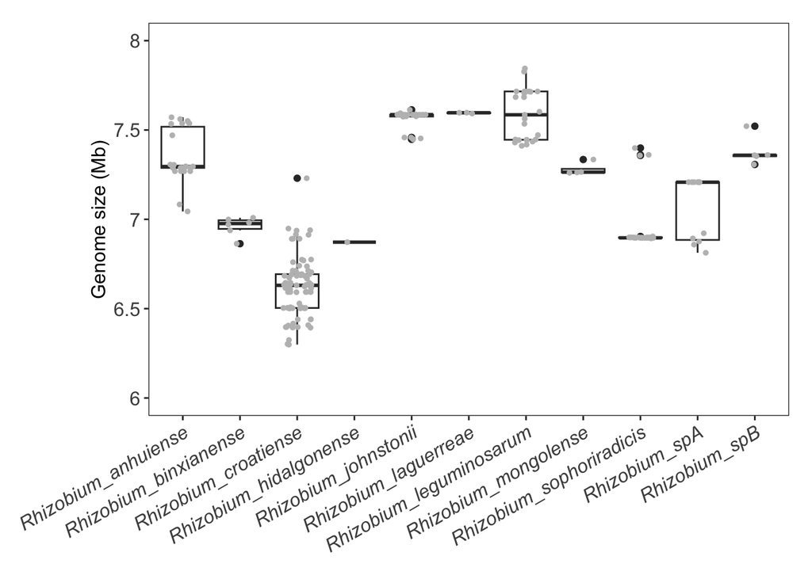

```r
# Prepare a box plot with overlapping datapoints
plot_boxplot <- ggplot(data, aes(x = Species, y = genome_size)) +
  geom_boxplot() +
  geom_jitter(colour="grey", size=1, alpha=1, width=0.25) +
  scale_x_discrete(name = NULL) +
  scale_y_continuous(name = "Genome size (Mb)",
                     limits = c(6000000,8000000),
                     breaks = c(6000000,6500000,7000000,7500000,8000000),
                     labels = function(x) x / 1e6) +
  theme_bw() +
  theme(axis.text.x = element_text(size = 12, angle = 30, hjust = 1, vjust=1, face="italic"),
        axis.text.y = element_text(size = 12),
        axis.title.x = element_text(size = 12),
        axis.title.y = element_text(size = 12),
        legend.position = "none",
        strip.background = element_blank(),
        strip.text = element_blank(),
        panel.grid.major = element_blank(),
        panel.grid.minor = element_blank(),
        plot.margin = unit(c(0.5,0.5,0.5,2), "cm"))
plot_boxplot
```

```r
# Save as a SVG file
svg(filename = "genome.size.svg", width=8.5, height=5)
plot_boxplot
dev.off()

# Save as a PDF file
pdf("genome.size.pdf", width=8.5, height=5)
plot_boxplot
dev.off()
```

Finally, clear the workspace in preparation for next analyses.

```r
# Clean the workspace
rm(list = ls())
```

# Average nucleotide identity (ANI)

Make a heatmap clustering the 216 Rhizobium isolates based on pairwise ANI values.

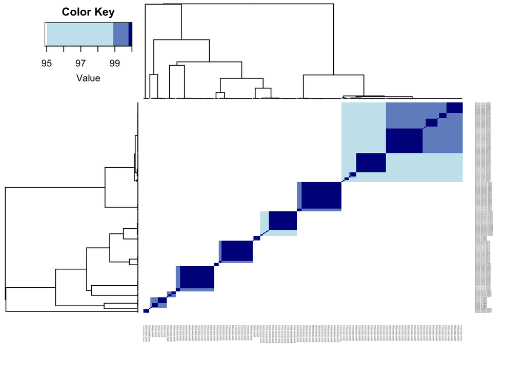

```r
# Load the data
data <- read.table("ANI_matrix.txt",
                   header = TRUE, row.names = 1)
data <- data.matrix(data)

# Set clustering variables
dist.pear <- function(x) as.dist(1-cor(t(x)))
hclust.ave <- function(x) hclust(x, method="average")

# Prepare heatmap
my_palette <- colorRampPalette(c("white", "light blue", "dark blue"))(n=4)
heatmap.2(data, trace=c("none"), density.info=c("none"), col=my_palette,
          breaks = c(94.9,95,98.9,99.8, 100),
          hclustfun = hclust.ave,
          distfun = dist.pear,
          lmat=matrix(c(4,2,3,1), nrow=2, ncol=2), key=T,
          cexRow=0.1, cexCol=0.1)
```

Now save the figure.

```r
# Export as a SVG file
svg(filename = 'ANI_matrix.svg')
heatmap.2(data, trace=c("none"), density.info=c("none"), col=my_palette,
          breaks = c(94.9,95,98.9,99.8, 100),
          hclustfun = hclust.ave,
          distfun = dist.pear,
          lmat=matrix(c(4,2,3,1), nrow=2, ncol=2), key=T,
          cexRow=0.1, cexCol=0.1)
dev.off()

# Explort as a PDF file
pdf('ANI_matrix.pdf')
heatmap.2(data, trace=c("none"), density.info=c("none"), col=my_palette,
          breaks = c(94.9,95,98.9,99.8, 100),
          hclustfun = hclust.ave,
          distfun = dist.pear,
          lmat=matrix(c(4,2,3,1), nrow=2, ncol=2), key=T,
          cexRow=0.1, cexCol=0.1)
dev.off()
```

Now clear the workspace in preparation for next analyses.

```r
# Clean the workspace
rm(list = ls())
```

# Pangenome visualization

Create UpSetR plots to visualize the results of the pangenome analysis. First, create species level data where a gene is considered present in a species as long as it shows up at least one, and then create the plot.

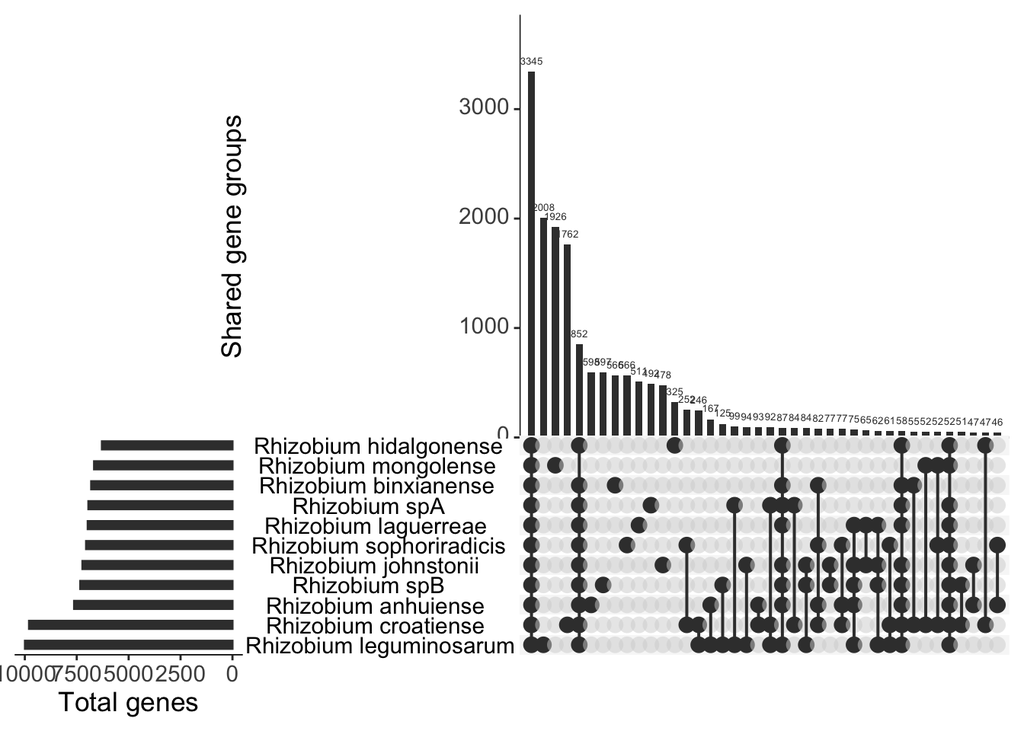

```r
# Load the data
gene_bean <- read.table("gene_presence_absence.tsv",
                        header = TRUE)

# Clean up the species names in the columns
gene_bean2 <- gene_bean %>%
  pivot_longer(
    cols = -Gene,
    names_to = "full_name",
    values_to = "PA",
    values_transform = list(PA = as.numeric)
  ) %>%
  mutate(Species = str_extract(full_name, "^[^_]+_[^_]+")) %>%
  group_by(Gene, Species) %>%
  summarise(PA = max(PA), .groups = "drop") %>%
  pivot_wider(names_from = Species, values_from = PA)

# Prep data for the upsetr plot
gene_bean3 <- gene_bean2 %>%
  dplyr::select(-Gene)

gene_bean3 <- as.data.frame(gene_bean3)
rownames(gene_bean3) <- NULL

# Prep the names for plot
colnames(gene_bean3) <- gsub("_", " ", colnames(gene_bean3))

plot1<-upset(
  gene_bean3,
  point.size = 3.5,
  order.by = "freq",
  sets = colnames(gene_bean3),
  mainbar.y.label = "Shared gene groups",
  sets.x.label = "Total genes",
  mb.ratio = c(0.6,0.4),
  text.scale = c(1.6, # intersection title
                           1.6, # size tick labels
                           1.6, # set size title
                           1.6, # set tick sizes
                           1.6, # species labels
                           0.8),
)
plot1
```

```r
# Save the plot
pdf("UpSetR.total.pdf", width=10, height=6)
plot1
dev.off()

# Clean the workspace
rm(list = ls())
```

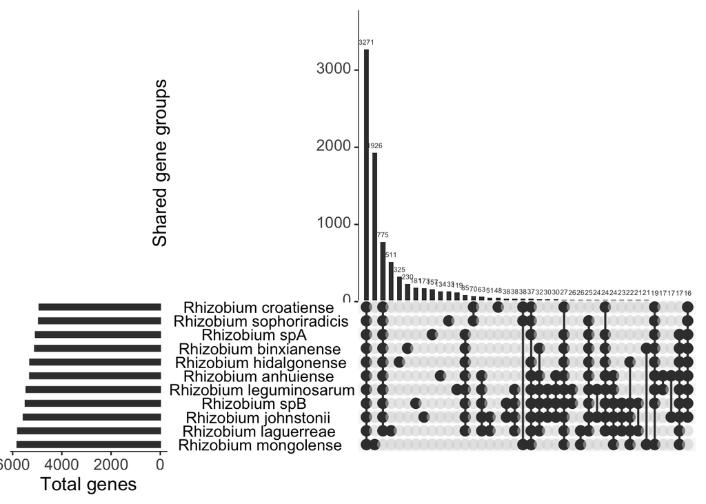

```r
# Load the data
gene_bean <- read.table("gene_presence_absence.tsv",
                        header = TRUE)

# Clean up the species names in the columns convert anything in the soft core genome to being in the core genome
gene_bean2 <- gene_bean %>%
  pivot_longer(
    cols = -Gene,
    names_to = "full_name",
    values_to = "PA",
    values_transform = list(PA = as.numeric)
  ) %>%
  mutate(Species = str_extract(full_name, "^[^_]+_[^_]+")) %>%
  group_by(Gene, Species) %>%
  summarise(PA = sum(PA) / n(), .groups = "drop") %>%
  #mutate(PA = replace(PA, PA <= 0.05, 0)) %>%
  mutate(PA = replace(PA, PA >= 0.95, 1)) %>%
  filter(PA == 0 | PA == 1) %>%
  pivot_wider(names_from = Species, values_from = PA) %>%
  drop_na()

# Prep data for the upsetr plot
gene_bean3 <- gene_bean2 %>%
  dplyr::select(-Gene)

gene_bean3 <- as.data.frame(gene_bean3)
rownames(gene_bean3) <- NULL

# Prep the names for plot
colnames(gene_bean3) <- gsub("_", " ", colnames(gene_bean3))

plot1<-upset(
  gene_bean3,
  point.size = 3.5,
  order.by = "freq",
  sets = colnames(gene_bean3),
  mainbar.y.label = "Shared gene groups",
  sets.x.label = "Total genes",
  mb.ratio = c(0.6,0.4),
  text.scale = c(1.6, # intersection title
                           1.6, # size tick labels
                           1.6, # set size title
                           1.6, # set tick sizes
                           1.6, # species labels
                           0.8),
)
plot1
```

```r
# Save the plot
pdf("UpSetR.core.pdf", width=10, height=6)
plot1
dev.off()

# Clean the workspace
rm(list = ls())
```

# Nod locus

Create an image showing the organization of nod genes in the representative isolates that have complete genomes. Also includ Rhizobium coratiense QUR0161 to have a second representative of the sv. phaseoli gamma-b allele.

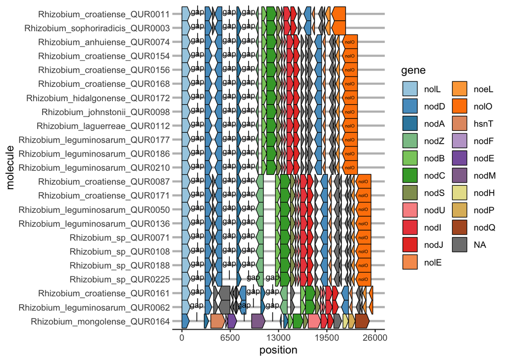

```r
# Load the data
genes <- read.table("nod_locus.txt",
                    header = TRUE, row.names = NULL, sep="\t")
gaps <- read.table("nod_breaks.txt",
                   header = TRUE, row.names = NULL, sep="\t")

# Order the isolates
genes$molecule <- factor(genes$molecule, levels = c("Rhizobium_mongolense_QUR0164","Rhizobium_leguminosarum_QUR0062","Rhizobium_croatiense_QUR0161","Rhizobium_sp_QUR0225","Rhizobium_sp_QUR0188","Rhizobium_sp_QUR0108","Rhizobium_sp_QUR0071","Rhizobium_leguminosarum_QUR0136","Rhizobium_leguminosarum_QUR0050","Rhizobium_croatiense_QUR0171","Rhizobium_croatiense_QUR0087","Rhizobium_leguminosarum_QUR0210","Rhizobium_leguminosarum_QUR0186","Rhizobium_leguminosarum_QUR0177","Rhizobium_laguerreae_QUR0112","Rhizobium_johnstonii_QUR0098","Rhizobium_hidalgonense_QUR0172","Rhizobium_croatiense_QUR0168","Rhizobium_croatiense_QUR0156","Rhizobium_croatiense_QUR0154","Rhizobium_anhuiense_QUR0074","Rhizobium_sophoriradicis_QUR0003","Rhizobium_croatiense_QUR0011"))
gaps$molecule <- factor(gaps$molecule, levels = c("Rhizobium_mongolense_QUR0164","Rhizobium_leguminosarum_QUR0062","Rhizobium_croatiense_QUR0161","Rhizobium_sp_QUR0225","Rhizobium_sp_QUR0188","Rhizobium_sp_QUR0108","Rhizobium_sp_QUR0071","Rhizobium_leguminosarum_QUR0136","Rhizobium_leguminosarum_QUR0050","Rhizobium_croatiense_QUR0171","Rhizobium_croatiense_QUR0087","Rhizobium_leguminosarum_QUR0210","Rhizobium_leguminosarum_QUR0186","Rhizobium_leguminosarum_QUR0177","Rhizobium_laguerreae_QUR0112","Rhizobium_johnstonii_QUR0098","Rhizobium_hidalgonense_QUR0172","Rhizobium_croatiense_QUR0168","Rhizobium_croatiense_QUR0156","Rhizobium_croatiense_QUR0154","Rhizobium_anhuiense_QUR0074","Rhizobium_sophoriradicis_QUR0003","Rhizobium_croatiense_QUR0011"))

# Order the gene colours
genes$gene <- factor(genes$gene, levels = c("nolL", "nodD", "nodA", "nodZ", "nodB", "nodC", "nodS", "nodU", "nodI", "nodJ", "nolE", "noeL", "nolO", "hsnT", "nodF", "nodE", "nodM", "nodH", "nodP", "nodQ"))

# Make the plot
myColors <- colorRampPalette(brewer.pal(12, "Paired"))(20)
plot1 <- ggplot(genes, aes(xmin = start, xmax = end,
                  y = molecule, fill = gene, label = gene,
                  forward = orientation)) +
  geom_gene_arrow(arrowhead_height = unit(5, "mm"), arrowhead_width = unit(1, "mm"),
                  arrow_body_height = unit(5, "mm")) +
  geom_gene_label() +
  geom_feature(
    data = gaps,
    aes(x = position, y = molecule)
  ) +
  geom_feature_label(
    data = gaps,
    aes(x = position, y = molecule, label = name)
  ) +
  #facet_wrap(~ molecule, scales = "free", ncol = 1) +
  scale_fill_manual(values = myColors) +
  theme_genes() +
  scale_x_continuous(limits = c(0,26000), breaks = c(0,6500,13000,19500,26000))
plot1
```

```r
# Save the plot
pdf("nod.locus.full.pdf", width=10, height=10)
plot1
dev.off()
```

Since many of them look identical, there is no need to have all of them in the main figure. Therefore, create a reduced version with just one representative per type.

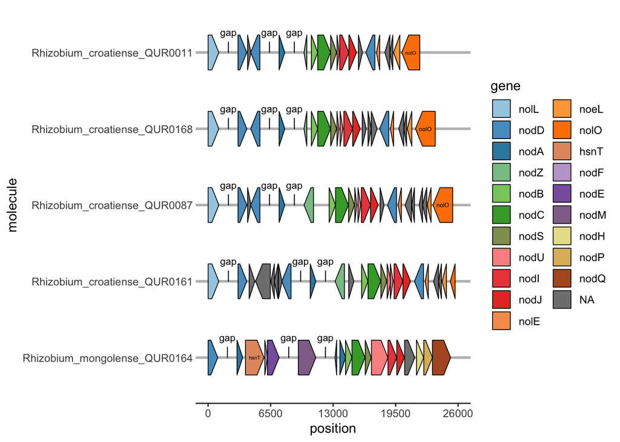

```r
# Filter to a smaller subset so that the image is more manageable
isolates.subset <- c("Rhizobium_mongolense_QUR0164","Rhizobium_croatiense_QUR0161","Rhizobium_croatiense_QUR0087","Rhizobium_croatiense_QUR0168","Rhizobium_croatiense_QUR0011")
filtered.genes <- genes %>%
  filter(molecule %in% isolates.subset)
filtered.gaps <- gaps %>%
  filter(molecule %in% isolates.subset)

# Make the plot
myColors <- colorRampPalette(brewer.pal(12, "Paired"))(20)
plot2 <- ggplot(filtered.genes, aes(xmin = start, xmax = end,
                  y = molecule, fill = gene, label = gene,
                  forward = orientation)) +
  geom_gene_arrow(arrowhead_height = unit(10, "mm"), arrowhead_width = unit(2, "mm"),
                  arrow_body_height = unit(10, "mm")) +
  geom_gene_label() +
  geom_feature(
    data = filtered.gaps,
    aes(x = position, y = molecule)
  ) +
  geom_feature_label(
    data = filtered.gaps,
    aes(x = position, y = molecule, label = name)
  ) +
  #facet_wrap(~ molecule, scales = "free", ncol = 1) +
  scale_fill_manual(values = myColors) +
  theme_genes() +
  scale_x_continuous(limits = c(0,26000), breaks = c(0,6500,13000,19500,26000))
plot2
```

```r
# Save the plot
pdf("nod.locus.subset.pdf", width=15, height=4)
plot2
dev.off()

# Clean the workspace
rm(list = ls())
```

# Symbiovar distribution

Lastly, summarize the distribution of symbiovar (subclades) across species

```r
# Load the data
data <- read.table("genome_stats.txt",
                    header = TRUE, row.names = NULL, sep="\t")

# Make the table
symbiovar.stats <- data %>%
  group_by(Species, Symbiovar) %>%
  summarize(Count = n())
symbiovar.stats.wide <- symbiovar.stats %>%
  pivot_wider(names_from = Symbiovar, values_from = Count) %>%
  replace(is.na(.), 0)

# Create a table rounded to 0 decimal place
kable(symbiovar.stats.wide, align = "l",
      caption = "Symbiovar distribution") %>%
  kable_classic(full_width = FALSE)
```

Symbiovar distribution

| Species | phaseoli_y-a | phaseoli_a | phaseoli_y-b | gallicum |
| --- | --- | --- | --- | --- |
| Rhizobium_anhuiense | 26 | 0 | 0 | 0 |
| Rhizobium_binxianense | 0 | 5 | 1 | 0 |
| Rhizobium_croatiense | 53 | 5 | 24 | 0 |
| Rhizobium_hidalgonense | 1 | 0 | 0 | 0 |
| Rhizobium_johnstonii | 23 | 0 | 0 | 0 |
| Rhizobium_laguerreae | 3 | 0 | 0 | 0 |
| Rhizobium_leguminosarum | 22 | 2 | 1 | 0 |
| Rhizobium_mongolense | 0 | 0 | 0 | 4 |
| Rhizobium_sophoriradicis | 27 | 0 | 3 | 0 |
| Rhizobium_spA | 0 | 11 | 0 | 0 |
| Rhizobium_spB | 0 | 5 | 0 | 0 |